# Temas Tratados en el Trabajo Práctico 1

- Diferencia entre Inteligencia e Inteligencia Artificial.
- Concepto de omnisciencia, aprendizaje y autonomía.
- Definición de Agente y sus características. Clasificación de Agentes según su estructura.
- Identificación y categorización del Entorno de Trabajo en tabla REAS.
- Caracterización del Entorno de Trabajo.

# Anotaciones

"Acordarse de la definición de agente"

# Ejercicios Teóricos

### 1. Defina con sus propias palabras inteligencia natural, inteligencia artificial y agente.

- Inteligencia natural: Es la inteligencia que tiene naturalmente el ser humano, animales y seres vivos las cuales son otorgadas por la naturaleza y nos da la capacidad de aprender, razonar, resolver problemas y adaptarnos a nuestro entorno.
- Inteligencia artificial: Es la inteligencia desarrollada en maquinas o programas las cuales pueden realizar tareas que normalmente requieren ser realizadas por humanos, estos son capaces de aprender, razonar y adaptarse al entorno.
- Agente: Es una entidad natural o artificial que percibe su entorno y actua de manera autonoma para lograr el resultado para el que fue creado.

### 2. ¿Qué es un agente racional?

- Un agente racional es una entidad que percibe su entorno y actua de manera que maximiza su rendimiento utilizando los sensores que posee para tomar las decisiones mas optimas.

### 3. ¿Un agente es siempre una computadora?

- No, un agente no siempre es una computadora existen tambien agentes organicos como proteinas creadas para combatir enfermedades o agentes mecanicos muy simples como el ejemplo del apagador de velas.

### 4. Defina Omnisciencia, Aprendizaje y Autonomía.

- Omnisciencia: Es la capacidad de un agente de conocer el estado actual completo de su entorno en todo momento, es aquel que tiene acceso a toda la informacion del entorno a pesar de que pueda cumplir con su tarea sin toda esa infromacion.
- Aprendizaje: Es la capacidad de un agente de mejorar su rendimiento y adaptar sus acciones a lo largo del tiempo, lo cual hace que pueda modificar sus decisiones basandose en experiencias previas.
- Autonomia: Es la capacidad de un agente de operar independientemente sin la intervencion o control humano directo, tomando sus propias decisiones y acciones.

### 5. Defina cada tipo de agente en función de su **estructura** y dé un ejemplo de cada categoría.

Las diferentes estructuras que podemos modelar para los agentes son:

- Agente Reactivo Simple:

  El agente reactivo simple, como su nombre lo indica, es una estructura primitiva que funciona de manera sencilla: el sensor toma lecturas del entorno, analiza "¿cómo es el mundo ahora?" y con esa información, junto con las "reglas de condición-acción" con las que fue creado, define que acción debe tomar para modificar el entorno y realiza la acción mediante actuadores.

  Un ejemplo de este tipo de agentes es una pava eléctrica, que al pulsar un botón empieza a calentar el agua hasta que el bimetálico alcance una cierta temperatura, independientemente de si tiene agua u otro líquido, o de si ya se calentó el líquido previamente.
- Agente Reactivo Basado en Modelos

  El agente reactivo basado en modelos tambíen cuenta con sensores que permite leer cúal es el estado del entorno actual, pero la información obtenida es almacenada y utilizada para mantener un seguimiento del entorno que no es evidente con la percepción instante a instante. Teniendo en cuenta tanto el modelo del entorno como los parámetros sensados, se refiere a las reglas "condición-acción", se determina que acción tomar y finalmente se acciona con los actuadores.

  Un ejemplo de este tipo de agentes es un robot que solo se mueve en un plano euclidiano: debe ir del punto A al punto B, y con trigonometría (modelo matemático) se calcula la ruta en linea recta.
- Agente Basados en Objetivos

  El agente basado en objetivos agrega con respecto al agente basado en modelos un bloque que analiza las acciones posibles y elije cualquier acción que permita llegar a una meta predeterminada.

  Un ejemplo de este tipo de agentes es un robot que solo se mueve en un plano euclidiano (como el ejemplo anterior) pero que es capaz de distinguir si hay un obstaculo e idear un camino (no necesariamente recto) que permita ir desde el punto A hasta el punto B (sea cual sea la ruta que se elija).
- Agente Basado en Utilidad

  El agente basado en utilidad agrega respecto al agente basado en utilidades un bloque de "utilidad" o "eficiencia". Esto quiere decir que, de entre todas las acciones posibles que me permitan llegar a mi meta, se tomará la acción que sea más "efectiva" (respecto a un parámetro de "comodidad").

  Un ejemplo de este tipo de agentes es el sistema de temperatura inteligente de un edificio, que busca ajustar la temperatura y la ventilación con la idea de maximizar el confort y minimizar el gasto energético simultaneamente.
- Agentes que Aprenden

  El agente que aprende agrega respecto al agente basado en utilidad una capacidad de mejorar sus comportamiento con el paso del tiempo a partir de la experiencia. Tiene bloques de "Elemento de aprendizaje" y otro de "Generador de Problemas" así como realimentación. Es capaz de provar diferentes métodos y calibrar la mejor ruta de acción.

  Un ejemplo de este tipo de agentes es un software de hospital, que basado en datos de miles de pacientes genera un diagnóstico para una persona particular a partir de los datos de salud de la misma.

### 6. Para los siguientes entornos de trabajo indique sus **propiedades**:

```
    a. Una partida de ajedrez.
```

[output not shown]

```
    b. Un partido de baloncesto.
```

[output not shown]

```
    c. El juego Pacman.
```

| Propiedades |  |
| --- | --- |
| Observabilidad | Total. Conozco la posición de todos los personajes y objetos. |
| Determinista/Estocástico | Determinista. Es un juego basado en un código informático, se tienen estrategias comprobadas para jugar, donde una acción determinada produce una respuesta acorde. |
| Episódico/Secuencial | Secuencial. Si ya se comió todos los "puntos" de un segmento, este hecho afectará mi juicio a la hora de decidir si ir o no por ese camino. |
| Estático/Dinámico | Dinámico. Los "fantasmitas" te persiguen incluso cuando planeas en qué dirección ir. |
| Discreto/Contínuo | Discreto. Cada acción esta acotada ("Frame Per Second"). |
| Agente | Individual. El único agente es el jugador. |

```
    d. El truco.
```

[output not shown]

```
    e. Las damas.
```

[output not shown]

```
    f. El juego tres en raya.
```

| Propiedades |  |
| --- | --- |
| Observabilidad | Total. Puedo ver la posición de todas las fichas en el tablero. |
| Determinista/Estocástico | Estocástico. Si bien menos que en el ajedrez, en el juego existen $9!$ posiciones posibles. |
| Episódico/Secuencial | Episódico. En el sentido de que cada partida nueva es independiente del resultado de la partida anterior (considerando al juego como "un conjunto de partidas"). |
| Estático/Dinámico | Estático. Durante el turno de un jugador, el contrincante no puede mover una de sus piezas. |
| Discreto/Contínuo | Discreto. Existe un número finito de acciones. |
| Agente | Multiagente. Existen 2 agentes: cada jugador. |

```
    g. Un jugador de Pokémon Go.
```

| Propiedades |  |
| --- | --- |
| Observabilidad | Parcial. El jugador no sabe la posición de casi ningún "pokemon" (criatura), a menos que este en la inmidiatez. |
| Determinista/Estocástico | Estocástico. No se sabe la posición exacta de ningún pokemon (por más de que el código del juego lo maneje de forma deterministica, a efectos prácticos el evento es probabilístico). |
| Episódico/Secuencial | Episódico. En el sentido de "atrapar criaturas", atrapar una criatura A no me determina si atraparé una criatura B ó C. |
| Estático/Dinámico | Dinámico. Los pokemons pueden aparecer y desaparecer mientras me acerco a atraparlos. |
| Discreto/Contínuo | Continuo. La posición de tanto el jugador como de los "pokemons" se distribuye de manera continua en toda la localidad (mapa). |
| Agente | Individual. A lo que "atrapar pokemons" respecta, el agente es único: el jugador. |

```
    h. Un robot explorador autónomo de Marte.
```

| Propiedades |  |
| --- | --- |
| Observabilidad | Parcial. El robot no conoce la totalidad del planeta. |
| Determinista/Estocástico | Estocástico |
| Episódico/Secuencial | Secuencial. Si el robot se desplaza muy rápido y se daña, este evento tendrá importancia para la toma de decisiones futuras. |
| Estático/Dinámico | Dinámico. A medida que el robot se mueve, el clima del planeta podría modificarse constantemente. |
| Discreto/Contínuo | Continuo. La posición del robot se debe determinar, y dicha coordenada se considera "continua". |
| Agente | Individual. Solo el robot acciona e interactúa con el entorno (al ser autónomo). |

### 7. Elabore una tabla REAS para los siguientes entornos de trabajo:

```
    a. Crucigrama.

    b. Taxi circulando.

    c. Robot clasificador de piezas.
```

| Entorno de trabajo | Descripcion | Rendimiento | Entorno | Actuadores | Sensores |
| --- | --- | --- | --- | --- | --- |
| Crucigrama | Se plantea un crucigrama con una serie de pistas para que resuelva una persona. | Crucigrama resuelto de forma correcta (que coincida con la solución). | Ambiente iluminado, lapicera, persona que resuelve el crucigrama. | Inteligencia de la persona y su capacidad de escribir. | Vista de la Persona. |
| Taxi | Taxi conducido por una persona. | Transportar a los pasajeros a su destino de forma segura y en un tiempo prudencial. | Calles, vehículos, peatones, señales de tránsito. | Motor, dirección, frenos, acelerador, caja de cambios accionados por el conductor. | Velocímetro, GPS, espejos retrovisores y vista del conductor. |
| Robot clasificador de piezas | Brazo robot de 6 grados de libertad con una pinza como efector final que le permite agarrar piezas que vienen en una cinta transportadora, identificarlas y colocarlas en su lugar según algún criterio. | Que los tipos de piezas resulten correctamente clasificadas según un parámetro indicado, sin errores y lo más rápido posible. | Cinta transportadora en movimiento, piezas, recipientes para depositar las piezas. | Servomotores de los ejes del brazo robot, pinzas. | Cámara o sensor de visión artificial, sensores de proximidad y de movimiento. |

# Ejercicios Prácticos

### 8. La Hormiga de Langton es un agente capaz de modificar el estado de la casilla en la que se encuentra para colorearla o bien de blanco o de negro. Al comenzar, la ubicación de la hormiga es una casilla aleatoria y mira hacia una de las cuatro casillas adyacentes. Si...

- ... la casilla sobre la que está es blanca, cambia el color del cuadrado, gira noventa grados a la derecha y avanza un cuadrado.
- ... la casilla sobre la que está es negra, cambia el color del cuadrado, gira noventa grados a la izquierda y avanza un cuadrado.

  Caracterice el agente con su tabla REAS y las propiedades del entorno para después programarlo en Python:

  ¿Observa que se repite algún patrón? De ser así, ¿a partir de qué iteración?

**Análisis REAS**

| Agente | Rendimiento | Entorno | Actuadores | Sensores |
| --- | --- | --- | --- | --- |
| Hormiga de Langton | Movimiento de la hormiga de acuerdo a las reglas y cambio de color cuando la hormiga pasa por cada casilla. | Grilla, casillas blancas y negras. | Comando mediante la función self.direction que usa una lista de direcciones y las funciones self.y y self.x que avanzan en la dirección determinada. | Sensor de color mediante la funcion current_self_color y de posicionamiento del mouse en el clic mediante mouse_x y mouse_y. |

**Propiedades del Entorno**

[output not shown]

Una vez programado en Python, se observó que la hormiga presenta un movimiento que se repite, realizando un movimiento similar a un espiral, que busca “escapar” de la pantalla. Este se vio despues de las 100 mil iteraciones. A esto se lo llama comportamiento emergente.

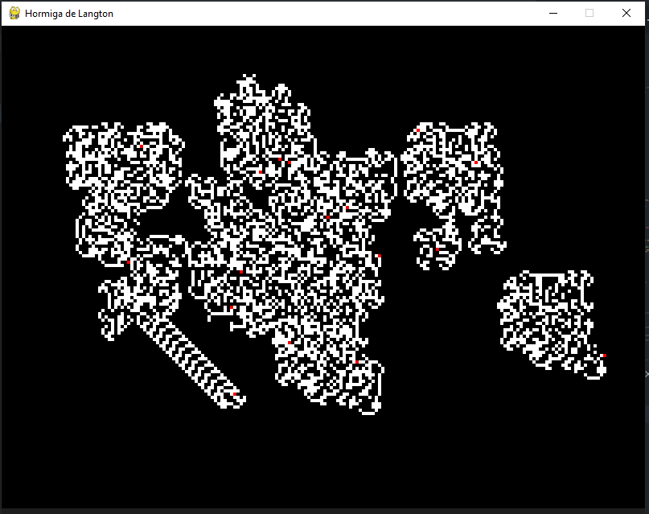

### 9. El Juego de la Vida de Conway consiste en un tablero donde cada casilla representa una célula, de manera que a cada célula le rodean 8 vecinas. Las células tienen dos estados: están *vivas* o *muertas*. En cada iteración, el estado de todas las células se tiene en cuenta para calcular el estado siguiente en simultáneo de acuerdo a las siguientes acciones:

- Nacer: Si una célula muerta tiene exactamente 3 células vecinas vivas, dicha célula pasa a estar viva.
- Morir: Una célula viva puede morir sobrepoblación cuando tiene más de tres vecinos alrededor o por aislamiento si tiene solo un vecino o ninguno.
- Vivir: una célula se mantiene viva si tiene 2 o 3 vecinos a su alrededor.

  Caracterice el agente con su tabla REAS y las propiedades del entorno para después programarlo en Python:

**Análisis REAS**

| Sistema | Rendimiento | Entorno | Actuadores | Sensores |
| --- | --- | --- | --- | --- |
| Juego de la Vida de Conway | Evolución correcta de las células siguiendo las reglas de Nacer, Morir, Vivir en cada intervalo de tiempo y representación de su estado en el tablero. | Tablero (matriz), casillas donde viven las células | Comandos para cambiar el estado de las células según las reglas, mediante la funcion *actualizar-grilla* | Lectura del estado actual del tablero: contabilidad del número de células vivas alrededor de cada una, medinte la funcion *contar-vecinos* |

**Propiedades del entorno**

| Propiedad |  |
| --- | --- |
| Observabilidad | Total. Se puede saber en todo momento qué células están vivas y cuáles no. |
| Determinista/Estocástico | Las células siempre cambian su estado en base a las reglas. |
| Episódico/Secuencial | Episódico. La célula modifica su estado en base a la cantidad de vecinos en cada iteración. |
| Estatico/Dinamico | Estatico. La configuración de las células cambia de iteración a iteración, pero no hay modificaciones intermedias que influyan en el poder de decision de evolucion de la célula. |
| Discreto/Continuo | Discreto en la práctica. La cantidad de células representadas es un número finito. |
| Agente | Multiagente. La cantidad de células vivas influye en la condición de vida de las otras. |

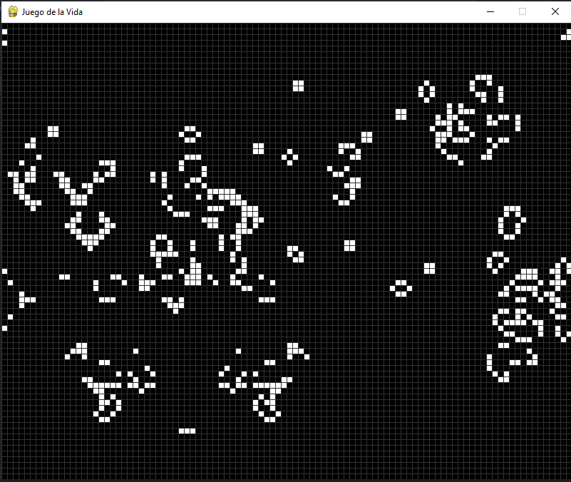

# Bibliografía

[Russell, S. & Norvig, P. (2004) *Inteligencia Artificial: Un Enfoque Moderno*. Pearson Educación S.A. (2a Ed.) Madrid, España](https://www.academia.edu/8241613/Inteligencia_Aritificial_Un_Enfoque_Moderno_2da_Edici%C3%B3n_Stuart_J_Russell_y_Peter_Norvig)

[Poole, D. & Mackworth, A. (2023) *Artificial Intelligence: Foundations of Computational Agents*. Cambridge University Press (3a Ed.) Vancouver, Canada](https://artint.info/3e/html/ArtInt3e.html)